# Tutorial_GEI_NJ

## Guided Tutorial for GEI-NJ

**Compiled: June 11, 2026**

For this tutorial, we use a published nodule section (Ye *et al*., 2024) for GEI-NJ analysis. This example dataset can be downloaded [here](https://zenodo.org/records/20639978).

```python
## Import modules
import anndata as ad
import scanpy as sc
import matplotlib.pyplot as plt
from gei_nj import (
    comb_depth_ratio,
    filt_snv_by_depth_ratio,
    add_callable_layer,
    revise_snv_ratio,
    impute_non_callable_by_snv_mean,
    plot_snv_pca_by_group,
    build_and_plot_nj
)
```

### Combining sequencing depth and SNV ratio AnnData objects

GEI-NJ uses sequencing depth and SNV ratio `AnnData` objects as input. The depth object, `ad_depth`, contains the corresponding sequencing depths, while the ratio object, `ad_ratio`, contains SNV ratios. These two objects are combined into a single AnnData object `adata` using `comb_depth_ratio`.

```python
## Load in SNV ratio and depth
ad_depth = ad.read_h5ad("unit_depth.h5ad")
ad_ratio = ad.read_h5ad("unit_ratio.h5ad")

## Combine depth and ratio into a single AnnData object
adata = comb_depth_ratio(ad_depth, ad_ratio)
```

```python
## Set group as the row names of the combined object
adata.obs["group"] = adata.obs_names.astype(str)
```

**What does the combined AnnData look like?**

```
AnnData object with n_obs × n_vars = 5 × 22944
    obs: 'group'
    layers: 'depth'
```

### SNV filtering

SNV filtering can be performed based on sequencing depth and mutation ratio using `filt_snv_by_depth_ratio`. In this step, `min_tot_depth` specifies the minimum total sequencing depth required for each retained SNV, `min_mut_depth` specifies the minimum mutant UMI support, and `min_mut_avg_ratio` specifies the minimum average mutation ratio. The average mutation ratio is computed within this function as mutated UMI divided by total UMI, which is equivalent to a depth-weighted average of unit-level mutation ratios.

```python
## Filter SNVs based on depth and ratio
adata = filt_snv_by_depth_ratio(adata, min_tot_depth=20, min_mut_depth=5, min_mut_avg_ratio=0.1)
```

```
SNV number before filter: 22944
SNV number after filter: 1971
```

### Construction of callable layers

Callable layers can be generated using `add_callable_layer`. This step records whether each SNV is callable in each cell group based on sequencing depth. The minimum depth required for a callable entry can be specified using `min_callable_depth`.

```python
## Construct callable layer based on depth
adata = add_callable_layer(adata, min_callable_depth=3)
```

```
Callable layer added to adata.layers['callable']
Minimum callable depth: 3
Total SNV entries: 9855
Callable SNV entries: 9088
Global callable fraction: 0.9222
```

```python
## (Optional) Remove SNVs that are not callable in any cell group
import scipy.sparse as sp
import numpy as np

C = adata.layers["callable"]

if sp.issparse(C):
    n_callable_cmb_per_snv = np.asarray(C.sum(axis=0)).ravel()
else:
    n_callable_cmb_per_snv = np.asarray(C).sum(axis=0)

keep_snv = n_callable_cmb_per_snv > 0
adata = adata[:, keep_snv].copy()

print(f"SNVs kept after removing zero-callable SNVs: {adata.n_vars}")
print(f"SNVs removed: {(~keep_snv).sum()}")
```

```
SNVs kept after removing zero-callable SNVs: 1971
SNVs removed: 0
```

### Revision of SNV ratios

To harmonize mutation signals across loci and reduce sensitivity to continuous ratio noise caused by cell aggregation and gene expression bias, SNV ratios are discretized by default using `revise_snv_ratio`. By default, ratios lower than 0.1 are set to 0, ratios higher than 0.9 are set to 1, and intermediate ratios are assigned to 0.5.

```python
## By default, the original SNV ratio will be moved to the adata.layers["original_ratio"] layer
adata = revise_snv_ratio(adata)
```

### Imputation of non-callable SNV ratios

GEI-NJ supports imputation of non-callable SNV entries using `impute_non_callable_by_snv_mean`. This function calculates the per-SNV mean from callable revised SNV ratios and uses this value to impute non-callable entries. The imputed SNV ratio matrix is stored in `adata.layers["geinj_state_imputed"]` and `adata.X` by default.

```python
## By default, this step stores the imputed SNV ratio matrix in adata.layers["geinj_state_imputed"]
## and updates adata.X to the imputed matrix
adata = impute_non_callable_by_snv_mean(adata, callable_layer="callable", output_layer="geinj_state_imputed")
```

```
Non-callable entries imputed by per-SNV callable mean
Callable entries: 9088
Non-callable entries: 767
Total SNV entries: 9855
Imputed matrix stored in adata.layers['geinj_state_imputed']
adata.X was updated to the imputed matrix
```

### Elbow detection (recommended)

GEI-NJ does not require a fixed strategy for selecting the number of PCs used for NJ tree construction. Users can specify this number based on scree plots, elbow points, prior knowledge, or other user-defined criteria. Here, we use the elbow point of the scree plot to guide PC selection. The elbow point is detected outside the core GEI-NJ functions using the `KneeLocator` function from the Python package `kneed`.

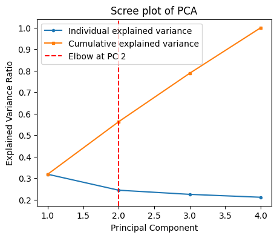

```python
from kneed import KneeLocator

## Detect the elbow point with the additional KneeLocator function
n_comps = min(adata.n_obs-1, adata.n_vars, 50)
sc.pp.pca(adata, n_comps=n_comps)
explained_var = adata.uns['pca']['variance_ratio']
explained_var_cum = explained_var.cumsum()

# Detect elbow point
kl = KneeLocator(range(1, len(explained_var)+1), explained_var, curve="convex", direction="decreasing")
elbow_PC = kl.elbow

plt.figure(figsize=(5,4))
plt.plot(range(1, len(explained_var)+1), explained_var, 'o-', markersize=3, label="Individual explained variance")
plt.plot(range(1, len(explained_var)+1), explained_var_cum, 's-', markersize=3, label="Cumulative explained variance")
plt.axvline(elbow_PC, color='r', linestyle='--', label=f'Elbow at PC {elbow_PC}')
plt.xlabel('Principal Component')
plt.ylabel('Explained Variance Ratio')
plt.legend()
plt.title('Scree plot of PCA')
plt.show()
plt.close()
```

### PC projection

The `plot_snv_pca_by_group` function retrieves PCA coordinates from the processed `AnnData` object and generates a two-dimensional scatter plot of user-specified PCs. By default, this function visualizes PC 1 and PC 2.

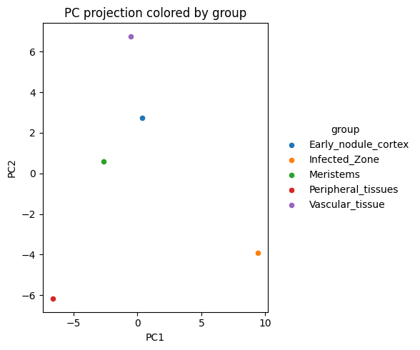

```python
plot_snv_pca_by_group(adata, group_by="group", alpha=1, size=20)
```

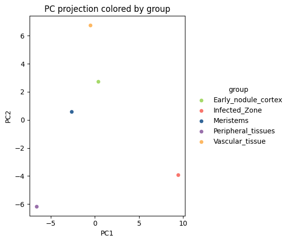

```python
## Color cell groups with colors set in a dictionary
group_colors = {'Early_nodule_cortex':'#a6d96a', 'Infected_Zone':'#f8766d', 'Meristems':'#336699',
                'Vascular_tissue':'#fdb863', 'Peripheral_tissues':'#9970ab'}
plot_snv_pca_by_group(adata, pcx=1, pcy=2, alpha=1, group_by="group", size=20, group_colors=group_colors)
```

### Generation of GEI-NJ trees

GEI-NJ trees are generated from the SNV PC matrix using `build_and_plot_nj()`. In the examples below, `K_tree=2` indicates that PC 1 and PC 2 are used for tree construction. GEI-NJ adds a non-SNV outgroup as a pseudo-founder cell group to root the inferred developmental structures. Several example layouts of `build_and_plot_nj()` are shown below.

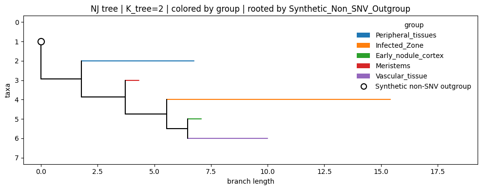

```python
tree = build_and_plot_nj(adata, figsize=(10, 4), group_key="group", K_tree=2)
```

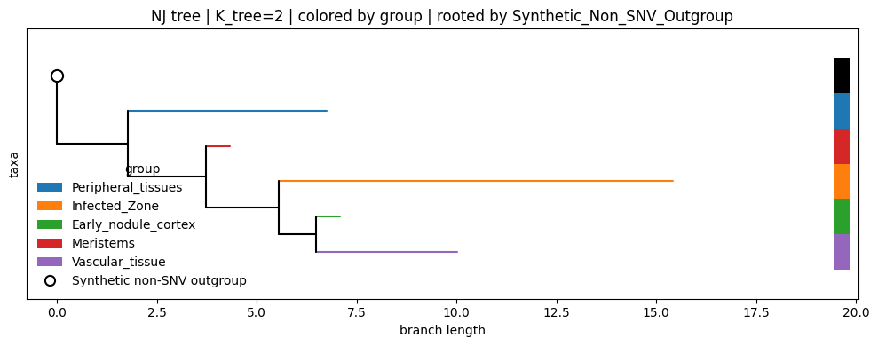

```python
tree = build_and_plot_nj(adata, figsize=(10, 4), group_key="group", K_tree=2, leafcolor_onside=True)
```

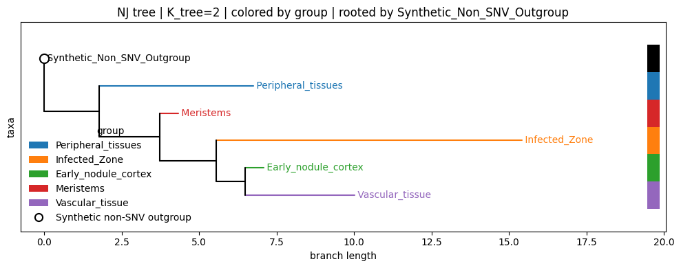

```python
tree = build_and_plot_nj(adata, figsize=(10, 4), group_key="group", K_tree=2, leafcolor_onside=True, show_leaf_labels=True)
```

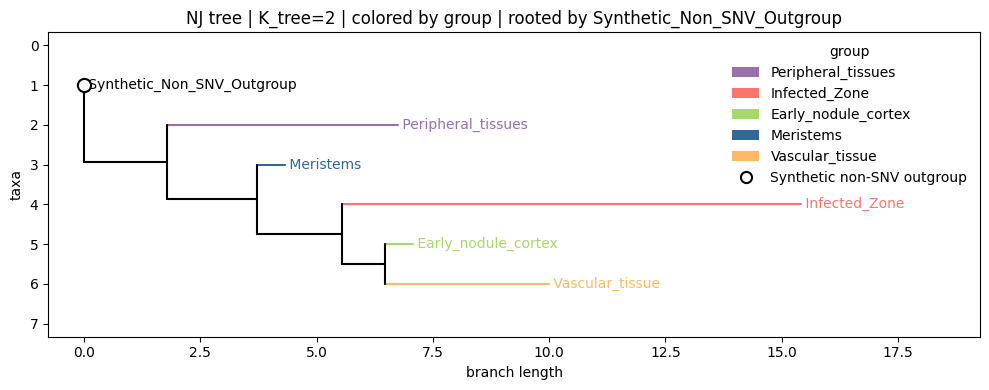

```python
## Color cell groups with colors set in a dictionary
group_colors = {'Early_nodule_cortex':'#a6d96a', 'Infected_Zone':'#f8766d', 'Meristems':'#336699',
                'Vascular_tissue':'#fdb863', 'Peripheral_tissues':'#9970ab'}
tree = build_and_plot_nj(adata, figsize=(10, 4), group_key="group", K_tree=2, show_leaf_labels=True, show_legend=True,
                         group_colors=group_colors)
```

### LOO assessment

To assess the stability of GEI-NJ tree topology with respect to PC selection, we demonstrate the leave-one-out (LOO) option implemented in `build_and_plot_nj()`. In the following example, LOO assessment was performed using the first 4 PCs by setting `pc_loo=True` and `K_pc_loo=4`. GEI-NJ then generated replicate NJ trees by excluding one of these PCs at a time and calculated LOO support for each internal split in the reference tree as the percentage of LOO trees in which that split was recovered. For visualization, only LOO support values greater than or equal to `pc_loo_min_support` are displayed on the GEI-NJ tree.

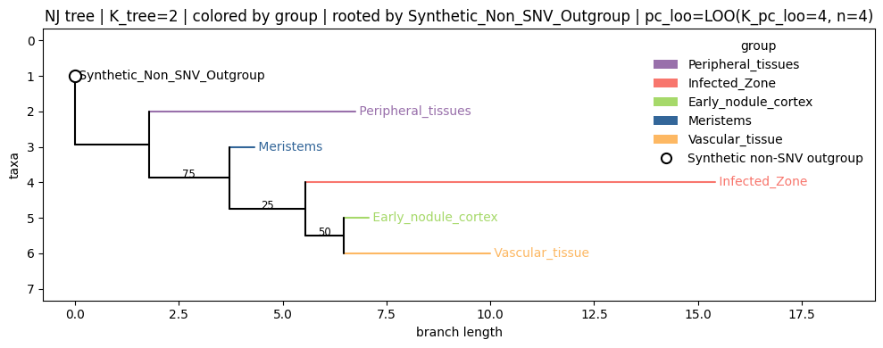

```python
tree = build_and_plot_nj(adata, figsize=(10, 4), group_key="group", K_tree=2, show_leaf_labels=True, show_legend=True,
                         group_colors=group_colors, pc_loo=True, K_pc_loo=4, pc_loo_min_support=25)
```